# Timeshifting of power using battery storage

This is a simple analysis to evaluate the opportunty of timeshifting power in the northen European day-ahead Elspot power market.

Data for the Elspot market was downloaded from [Nordpool](http://www.nordpoolspot.com/) and preprocessed into a SQLite database file. All prices are in EUR. From this data I calculate the intraday trough-to-peak for each day and study it’s distribution. The intraday trough-to-peak represent the maximum timeshift opportunity.

```r
conn <- dbConnect(dbDriver("SQLite"), "nordpool.db", flags=SQLITE_RO)
rs <- dbSendQuery(conn, "SELECT date, area, MAX(price)-MIN(price) as ttp FROM elspot GROUP BY date, area")
data <- fetch(rs)
cdata <- ddply(data, "area", summarise, ttp.mean=mean(ttp), ttp.75th=quantile(ttp, .75))
summary(data)
```

```
##      date               area                ttp
##  Length:500         Length:500         Min.   :  0.000
##  Class :character   Class :character   1st Qu.:  5.758
##  Mode  :character   Mode  :character   Median : 10.435
##                                        Mean   : 15.025
##                                        3rd Qu.: 17.630
##                                        Max.   :162.930
```

Mean and 75th percentile prices per area:

```r
knitr::kable(cdata)
```

| area | ttp.mean | ttp.75th |
| --- | --- | --- |
| Bergen | 7.192143 | 8.3775 |
| DK1 | 22.916429 | 25.2725 |
| DK2 | 22.235357 | 23.3775 |
| EE | 21.203214 | 24.5125 |
| ELE | 10.912500 | 16.1575 |
| FI | 19.013214 | 25.5800 |
| Kr.sand | 7.256429 | 7.2525 |
| LT | 31.858571 | 37.2875 |
| LV | 19.585357 | 35.5600 |
| Molde | 11.431429 | 11.5250 |
| Oslo | 7.475000 | 8.3775 |
| SE1 | 12.904643 | 13.6625 |
| SE2 | 12.904643 | 13.6625 |
| SE3 | 14.502857 | 13.9400 |
| SE4 | 16.191852 | 16.0750 |
| SYS | 9.966296 | 10.2450 |
| Tr.heim | 11.247037 | 11.2100 |
| Troms | 11.247037 | 11.2100 |

Distribution of trough-to-peak per area:

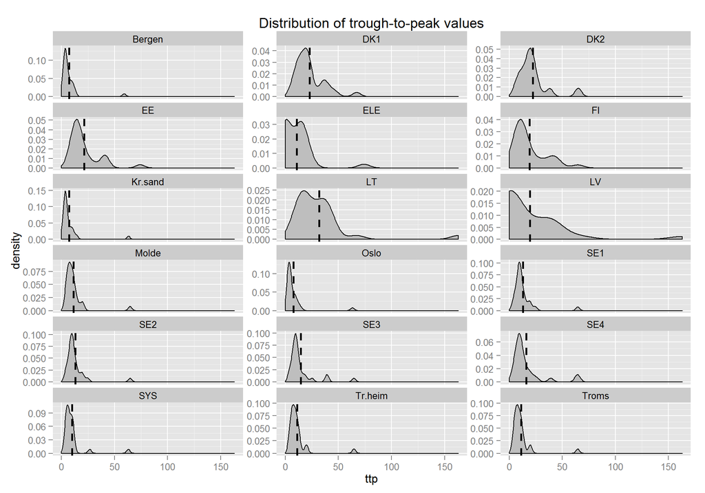

```r
ggplot(data, aes(x=ttp)) +
  ggtitle("Distribution of trough-to-peak values") +
  geom_density(fill='gray') +
  geom_vline(data=cdata, aes(xintercept=ttp.mean), linetype="dashed", size=1) +
  facet_wrap(~ area, ncol=3, scales="free_y")
```

If the trough-to-peak value is higher than the amortized cost per MWh of power storage we can profitably timeshift power. I found several sources online for a price of 140USD for Li-ion cells when buying large quantities. I don’t have data on cost of the inverters and substations. I assume they double the cost. For amortizing the cells I do a straight amortization over 5000 cycles (can be changed for a better model).

```r
installation_cost = 140 * 1000
amortized_cost = 2 * installation_cost / 5000
```

Amortized cost of Li-ion batteries per MWh in USD: 56